# IE 582 HOMEWORK 3

# 2019702075

```python
#import packa
import pandas as pd
import numpy as np
import matplotlib.pyplot as plt
```

```python
#import data
df = pd.read_csv("D://Dersler//IE 582//HW3//GercekZamanliTuketim-01012016-01122020.csv",encoding= 'unicode_escape')
```

```python
df.head() #Column names should be changed
```

|  | Tarih | Saat | Tüketim Miktarý (MWh) |
| --- | --- | --- | --- |
| 0 | 01.01.2016 | 00:00 | 26.277,24 |
| 1 | 01.01.2016 | 01:00 | 24.991,82 |
| 2 | 01.01.2016 | 02:00 | 23.532,61 |
| 3 | 01.01.2016 | 03:00 | 22.464,78 |
| 4 | 01.01.2016 | 04:00 | 22.002,91 |

```python
#change column names
column = {'Tarih':'Date', 'Saat':'Time', 'Tüketim Miktarý (MWh)': 'Consumption Amount (MWh)'}
df.rename(columns = column, inplace = True)
```

First of all, in Turkey, the regulation to change the clocks was abolished in 2016. So, in March 2016, clocks moved forward 1 hour. This situation affects our training data while shifting. For this reason, to prevent this effect, we should remove the whole week that clocks move forward because it will be problem while shifting.. The time range should be removed is between 21.03.2016 Monday 00:00 and 27.03.2016 Sunday 23:00. After that, training data created and it can be used for regression.

```python
#create booelan true array to match while filtering
filt = np.full(len(df), True)
for i in range (21,28):
    filt = (df['Date'] != f'{i}.03.2016') & filt
```

```python
print(len(df)-len(df[filt])) # It is correct 24*7=168. 168 row is deleted from data.
df=df[filt]; df=df.reset_index(drop=True)
```

```
168
```

```python
print(df.head())
len(df)
```

```
         Date   Time Consumption Amount (MWh)
0  01.01.2016  00:00                26.277,24
1  01.01.2016  01:00                24.991,82
2  01.01.2016  02:00                23.532,61
3  01.01.2016  03:00                22.464,78
4  01.01.2016  04:00                22.002,91
```

```
42960
```

```python
#change comma and dot in Consumption Amount and delete comma in order to prevent problem in later calculation
df['Consumption Amount (MWh)'] = df['Consumption Amount (MWh)'].str.replace(".","")
df['Consumption Amount (MWh)'] = df['Consumption Amount (MWh)'].str.replace(",",".").astype(float)
```

```python
df.head() #Data is ready
```

|  | Date | Time | Consumption Amount (MWh) |
| --- | --- | --- | --- |
| 0 | 01.01.2016 | 00:00 | 26277.24 |
| 1 | 01.01.2016 | 01:00 | 24991.82 |
| 2 | 01.01.2016 | 02:00 | 23532.61 |
| 3 | 01.01.2016 | 03:00 | 22464.78 |
| 4 | 01.01.2016 | 04:00 | 22002.91 |

# Question a)

```python
#create the lag168
df['lag_168'] = df['Consumption Amount (MWh)'].shift(periods = 168)
```

```python
#create the lag 48
df['lag_48'] = df['Consumption Amount (MWh)'].shift(periods = 48)
##After creating lag, remove NaN value. It will be problem while regression. NaN values appear for the first rows.
df.dropna(how="any",inplace = True)
```

```python
df = df.reset_index(drop=True)
df.head() ##lag_168 and lag_48 are created to estimate consumption in test
```

|  | Date | Time | Consumption Amount (MWh) | lag_168 | lag_48 |
| --- | --- | --- | --- | --- | --- |
| 0 | 08.01.2016 | 00:00 | 28602.02 | 26277.24 | 29189.27 |
| 1 | 08.01.2016 | 01:00 | 27112.37 | 24991.82 | 27614.02 |
| 2 | 08.01.2016 | 02:00 | 25975.34 | 23532.61 | 26578.97 |
| 3 | 08.01.2016 | 03:00 | 25315.55 | 22464.78 | 25719.19 |
| 4 | 08.01.2016 | 04:00 | 25128.15 | 22002.91 | 25864.63 |

```python
#getting index of November 01 at time 00:00 to split data as train and test
sp_index = df.index[(df['Date']=='01.11.2020') & (df['Time']=='00:00')].tolist()[0]
#42048
```

```python
#create the train_data
train_data = df.iloc[0:sp_index,:] ; train_data = train_data.reset_index()
train_data = train_data.drop('index', axis = 1)
```

```python
#create the test_data
test_data = df.iloc[sp_index:,:] ; test_data = test_data.reset_index()
test_data = test_data.drop('index', axis = 1)
```

```python
#calculating MAPE
#convert numpy array column to calculate with element wise operation
test_actual = np.array(test_data.iloc[:,2])
test_lag168 = np.array(test_data.iloc[:,3])
test_lag48  = np.array(test_data.iloc[:,4])
test_data['Percentage_Error_168'] = np.divide(np.abs(np.subtract(test_actual,test_lag168)),test_actual)*100
test_data['Percentage_Error_48'] = np.divide(np.abs(np.subtract(test_actual,test_lag48)),test_actual)*100
```

```python
test_data.head()
```

|  | Date | Time | Consumption Amount (MWh) | lag_168 | lag_48 | Percentage_Error_168 | Percentage_Error_48 |
| --- | --- | --- | --- | --- | --- | --- | --- |
| 0 | 01.11.2020 | 00:00 | 28701.62 | 29481.33 | 29066.51 | 2.716606 | 1.271322 |
| 1 | 01.11.2020 | 01:00 | 27254.15 | 28002.28 | 27838.89 | 2.745013 | 2.145508 |
| 2 | 01.11.2020 | 02:00 | 26078.57 | 27115.39 | 26940.11 | 3.975755 | 3.303632 |
| 3 | 01.11.2020 | 03:00 | 25449.47 | 26415.11 | 26260.80 | 3.794342 | 3.188004 |
| 4 | 01.11.2020 | 04:00 | 25324.01 | 26075.07 | 26097.96 | 2.965802 | 3.056191 |

```python
#calculate mape_168
mape_168 = np.mean(test_data['Percentage_Error_168'])
print(str(mape_168)+'%') # %3.449188
#calculate mape_48
mape_48 = np.mean(test_data['Percentage_Error_48'])
print(str(mape_48)+'%') # %8.060314
```

```
3.4491884826122794%
8.060314509077507%
```

```python
##copy mape, for question f, later box plot will be made
qa_lag168 = test_data['Percentage_Error_168']
qa_lag48 = test_data['Percentage_Error_48']
```

```python
#summary statistics
print(qa_lag168.describe())
print(qa_lag48.describe())
#lag168 gives 3.449 mape value. Also the standard deviation is 3.12. The best error for lag 168 is only 0.00852. On the other hand, the worst case gives 19.562 error.
#lag48 gives 8.06 mape value. Also the standard deviation is 8.55. The best error for lag 168 is only 0.0095447. On the other hand, the worst case gives 43.770746 error.
```

```
count    744.000000
mean       3.449188
std        3.128194
min        0.008521
25%        1.335853
50%        2.514032
75%        4.548818
max       19.565225
Name: Percentage_Error_168, dtype: float64
count    744.000000
mean       8.060315
std        8.550469
min        0.009547
25%        1.643485
50%        5.729723
75%       10.106987
max       43.770746
Name: Percentage_Error_48, dtype: float64
```

```python
##On 05.11.2020 and 08.11.2020 at 09.00 a.m, lag 168 and lag 48 give the worst error, respectively.

print(test_data.iloc[test_data['Percentage_Error_168'].argmax()])
print(test_data.iloc[test_data['Percentage_Error_48'].argmax()])
```

```
Date                        05.11.2020
Time                             09:00
Consumption Amount (MWh)       36927.2
lag_168                        29702.3
lag_48                         34985.7
Percentage_Error_168           19.5652
Percentage_Error_48            5.25757
Name: 105, dtype: object
Date                        08.11.2020
Time                             09:00
Consumption Amount (MWh)       25483.7
lag_168                          25314
lag_48                         36638.1
Percentage_Error_168          0.665994
Percentage_Error_48            43.7707
Name: 177, dtype: object
```

Comment for question a): If we look at the results which are calculated by MAPE for each period, lag168 and lag48 approach give 3.449 and 8.060 values of MAPE, respectively. MAPE is a measure of prediction accuracy of a forecasting method in statistics. Smaller MAPE values mean higher accuracy. For this reason, MAPE_168 with 3.449% value is more suitable to forecast energy consumption amount for specific date and time rather than MAPE_48 as expected because lag168 consider the same day; altough lag48 consider the different day. As a result, seasonality in terms of day is important for energy consumption. Moreover, in the summary statistics results, standard deviation for lag168 and lag48 are 3.12 and 8.55, respectively. Also, minimum errors are 0.00852 and 0.0095, respectively. On the other hand, on 05.11.2020 and 08.11.2020 at 09 a.m, lag168 and lag48 gives the worst error.

# Question b)

```python
#reorder column as in homework description
df = df[['Date','Time','lag_48','lag_168','Consumption Amount (MWh)']]
```

```python
df.head() #Data is ready
```

|  | Date | Time | lag_48 | lag_168 | Consumption Amount (MWh) |
| --- | --- | --- | --- | --- | --- |
| 0 | 08.01.2016 | 00:00 | 29189.27 | 26277.24 | 28602.02 |
| 1 | 08.01.2016 | 01:00 | 27614.02 | 24991.82 | 27112.37 |
| 2 | 08.01.2016 | 02:00 | 26578.97 | 23532.61 | 25975.34 |
| 3 | 08.01.2016 | 03:00 | 25719.19 | 22464.78 | 25315.55 |
| 4 | 08.01.2016 | 04:00 | 25864.63 | 22002.91 | 25128.15 |

```python
#splitting data as train and test
#getting index of November 01 at time 00:00 to split data as train and test
sp_index = df.index[(df['Date']=='01.11.2020') & (df['Time']=='00:00')].tolist()[0]
```

```python
#create the train_data
train_reg = df.iloc[0:sp_index,:] ; train_reg = train_reg.reset_index()
train_reg = train_reg.drop('index', axis = 1)
```

```python
#create the test_data
test_reg = df.iloc[sp_index:,:] ; test_reg = test_reg.reset_index()
test_reg = test_reg.drop('index', axis = 1)
```

Linear Regression

```python
#import packages
from sklearn import linear_model
from sklearn.metrics import r2_score
```

```python
#create responses and covariate for regression
train_x = train_reg[["lag_48","lag_168"]]
train_y = train_reg["Consumption Amount (MWh)"]
test_x = test_reg[["lag_48","lag_168"]]
test_y = test_reg["Consumption Amount (MWh)"]
```

```python
#Linear Regression
reg = linear_model.LinearRegression()
```

```python
#train the model using the training sets
reg.fit(train_x, train_y)
```

```
LinearRegression()
```

There exists no R type regression summary report in python. Hence, we call the function seperately to show results

```python
#R_square
print('Variance score(R^2): {}'.format(r2_score(test_y, reg.predict(test_x))))
```

```
Variance score(R^2): 0.8108855765048621
```

```python
#regression coefficient
#model intercept and slope
print('intercept:', round(reg.intercept_,3))
print('slope for lag_48:  '+ f'{str(round(reg.coef_[0],3))}')
print('slope for lag_168: '+ f'{str(round(reg.coef_[1],3))}')
```

```
intercept: 1570.189
slope for lag_48:  0.309
slope for lag_168: 0.643
```

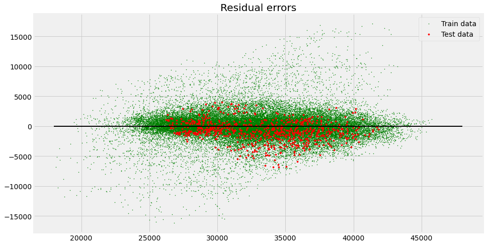

```python
#plot for residual error
plt.figure(figsize=(16,8))
## setting plot style
plt.style.use('fivethirtyeight')
## plotting residual errors in training data
plt.scatter(reg.predict(train_x), reg.predict(train_x) - train_y,
            color = "green", s = 1, label = 'Train data')
## plotting residual errors in test data
plt.scatter(reg.predict(test_x), reg.predict(test_x) - test_y,
            color = "red", s = 10, label = 'Test data')

## plotting line for zero residual error
plt.hlines(y = 0, xmin = 18000, xmax = 48000, linewidth = 2)

## plotting legend
plt.legend(loc = 'upper right')

## plot title
plt.title("Residual errors")

## function to show plot
plt.show()
```

```python
#add predictions column to test dataframe
predictions = reg.predict(test_x)
test_reg['Prediction'] = predictions
test_reg = test_reg.round({'Prediction':2})
```

```python
#MAPE Calculation
test_reg['Absolute_Percentage_Error'] = np.divide(np.abs(np.subtract(test_reg.iloc[:,4],test_reg.iloc[:,5])),test_reg.iloc[:,4])*100
mape_reg = np.mean(test_reg['Absolute_Percentage_Error'])
print('Mean Absolute Percentage Error for Test Data: '+ '%'+str(round(mape_reg,3)))
```

```
Mean Absolute Percentage Error for Test Data: %4.23
```

```python
##copy mape, for question f, later box plot will be made
qb_reg = test_reg['Absolute_Percentage_Error']
```

```python
#summary statistics
print(qb_reg.describe())
###MAPE equals to 4.229. Standard deviation is 3.37. Also, minimum and maximum values are 0.004339 and 16.611269, respectively.
```

```
count    744.000000
mean       4.229593
std        3.378827
min        0.004339
25%        1.826038
50%        3.308442
75%        5.704960
max       16.611269
Name: Absolute_Percentage_Error, dtype: float64
```

Comment for question b): If we look at the results which are calculated by MAPE for regression with two lag periods, MAPE is founded as 4.23%. The value is better than lag48 (%8.06) result in part a, while it is worse than lag168 result (%3.44). Moreover, in summary statistic, maximumum error is smaller than both approaches in part a. Also, standard deviation is very small with the value of 3.378. On the other hand, minimum error for linear regression is 0.004339. In the linear regression R^2 value is founded as 0.81, and this shows that linear regression model is highly accurate for this data. Moreover, in residual plot above, the majority of deviations are close to zero. Finally, the linear model can be written as with beta values: Y = 1570.189 + lag_48*0.309 + lag_168*0.643. These beta values are founded above.

# Question c)

```python
#create the train_data
train_c = df.iloc[0:sp_index,:] ; train_c = train_c.reset_index()
train_c = train_c.drop('index', axis = 1)
#create the test_data
test_c = df.iloc[sp_index:,:] ; test_c = test_c.reset_index()
test_c = test_c.drop('index', axis = 1)
#array to hold mape score for each time
test_scores = []
##create dataframe to hold predictions and actual value to plot residuals later
test_hold = pd.DataFrame()
train_hold= pd.DataFrame()
###filter data for each hour,then make regression
for i in range(0,24):
    if i <= 9: #because of notation, firstly regression is made for between the time 0 and 9.
        train = train_c[train_c['Time'] == f'0{i}:00']; train = train.reset_index(drop=True)
        test  = test_c[test_c['Time']   == f'0{i}:00']; test  = test.reset_index(drop=True)
    if i > 9:
        train = train_c[train_c['Time'] == f'{i}:00']; train = train.reset_index(drop=True)
        test  = test_c[test_c['Time']   == f'{i}:00']; test  = test.reset_index(drop=True)
    #create responses and covariates for train and test
    train_x = train[['lag_48','lag_168']]
    train_y = train[['Consumption Amount (MWh)']]
    test_x = test[['lag_48','lag_168']]
    test_y = test[['Consumption Amount (MWh)']]
    #linear regression
    reg = linear_model.LinearRegression()
    #train the model using the training sets
    reg.fit(train_x,train_y)
    #prediction
    predictions = reg.predict(test_x)
    predict_train = reg.predict(train_x)
    #add predictions as column with decimal 2.
    test = pd.concat([test, pd.DataFrame(predictions)], axis=1); test.rename(columns={0:'Predictions'}, inplace=True)
    test = test.round({'Predictions':2})

    train=pd.concat([train, pd.DataFrame(predict_train)],axis=1); train.rename(columns={0:'Predictions'}, inplace=True)
    train = train.round({'Predictions':2})
    #MAPE Calculation
    test['Absolute_Percentage_Error'] = np.divide(np.abs(np.subtract(test.iloc[:,4],test.iloc[:,5])),test.iloc[:,4])*100
    mape_reg = np.mean(test['Absolute_Percentage_Error'])
    test_scores.append(mape_reg)
    if i <= 9:
        print('Mean Absolute Percentage Error for the Hour' + f' 0{i}:00 with test data: ' +  str(round(mape_reg,3)) +
              '%')

    if i > 9:
        print('Mean Absolute Percentage Error for the Hour' + f' {i}:00 with test data: '+str(round(mape_reg,3)) +
              '%')
    #append results to dataframe which will be used to plotting residuals later
    test_hold = test_hold.append(test)
    train_hold = train_hold.append(train)
```

```
Mean Absolute Percentage Error for the Hour 00:00 with test data: 3.264%
Mean Absolute Percentage Error for the Hour 01:00 with test data: 3.284%
Mean Absolute Percentage Error for the Hour 02:00 with test data: 3.419%
Mean Absolute Percentage Error for the Hour 03:00 with test data: 3.203%
Mean Absolute Percentage Error for the Hour 04:00 with test data: 3.183%
Mean Absolute Percentage Error for the Hour 05:00 with test data: 3.188%
Mean Absolute Percentage Error for the Hour 06:00 with test data: 3.148%
Mean Absolute Percentage Error for the Hour 07:00 with test data: 3.777%
Mean Absolute Percentage Error for the Hour 08:00 with test data: 4.676%
Mean Absolute Percentage Error for the Hour 09:00 with test data: 5.489%
Mean Absolute Percentage Error for the Hour 10:00 with test data: 6.09%
Mean Absolute Percentage Error for the Hour 11:00 with test data: 6.276%
Mean Absolute Percentage Error for the Hour 12:00 with test data: 6.545%
Mean Absolute Percentage Error for the Hour 13:00 with test data: 6.685%
Mean Absolute Percentage Error for the Hour 14:00 with test data: 6.483%
Mean Absolute Percentage Error for the Hour 15:00 with test data: 6.085%
Mean Absolute Percentage Error for the Hour 16:00 with test data: 5.149%
Mean Absolute Percentage Error for the Hour 17:00 with test data: 4.613%
Mean Absolute Percentage Error for the Hour 18:00 with test data: 3.743%
Mean Absolute Percentage Error for the Hour 19:00 with test data: 3.435%
Mean Absolute Percentage Error for the Hour 20:00 with test data: 3.163%
Mean Absolute Percentage Error for the Hour 21:00 with test data: 3.165%
Mean Absolute Percentage Error for the Hour 22:00 with test data: 3.165%
Mean Absolute Percentage Error for the Hour 23:00 with test data: 3.385%
```

```python
##Test score
score_df = pd.DataFrame(test_scores, columns = ['MAPE'])
score_df
```

|  | MAPE |
| --- | --- |
| 0 | 3.263674 |
| 1 | 3.283923 |
| 2 | 3.419483 |
| 3 | 3.203033 |
| 4 | 3.182972 |
| 5 | 3.187623 |
| 6 | 3.148337 |
| 7 | 3.777419 |
| 8 | 4.675844 |
| 9 | 5.488707 |
| 10 | 6.090359 |
| 11 | 6.275687 |
| 12 | 6.544517 |
| 13 | 6.685464 |
| 14 | 6.482932 |
| 15 | 6.084540 |
| 16 | 5.149147 |
| 17 | 4.612603 |
| 18 | 3.743388 |
| 19 | 3.435412 |
| 20 | 3.163088 |
| 21 | 3.164629 |
| 22 | 3.164702 |
| 23 | 3.384693 |

```python
#before plotting reset index
train_hold = train_hold.reset_index()
test_hold = test_hold.reset_index()
##copy mape, for question f, later box plot will be made
qc_reg = test_hold['Absolute_Percentage_Error']
```

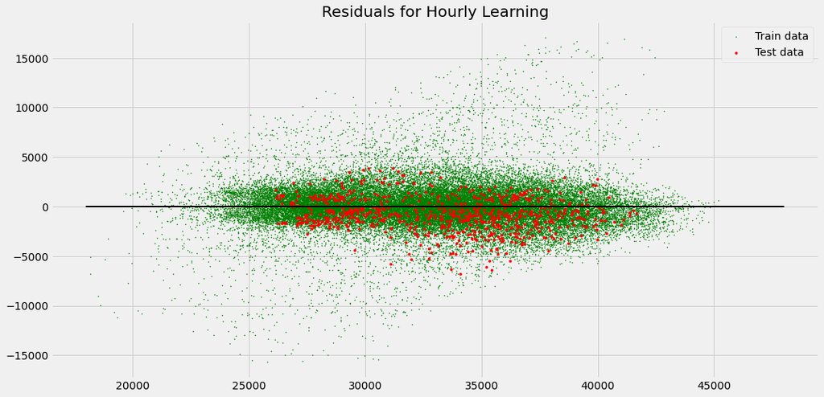

```python
#plot for residual error with hourly learning
plt.figure(figsize=(16,8))
## setting plot style
plt.style.use('fivethirtyeight')
## plotting residual errors in training data
plt.scatter(train_hold['Predictions'], (np.array(train_hold['Predictions'])-np.array(train_hold['Consumption Amount (MWh)'])),
            color = "green", s = 1, label = 'Train data')
#plotting residual errors in test data
plt.scatter(test_hold['Predictions'], (np.array(test_hold['Predictions'])-np.array(test_hold['Consumption Amount (MWh)'])),
            color = "red", s = 10, label = 'Test data')

#plotting line for zero residual error
plt.hlines(y = 0, xmin = 18000, xmax = 48000, linewidth = 2)

#plotting legend
plt.legend(loc = 'upper right')

#plot title
plt.title("Residuals for Hourly Learning")

#function to show plot
plt.show()
```

```python
#summary statistics of MAPE values
score_df.describe()
```

|  | MAPE |
| --- | --- |
| count | 24.000000 |
| mean | 4.358841 |
| std | 1.351521 |
| min | 3.148337 |
| 25% | 3.199180 |
| 50% | 3.589400 |
| 75% | 5.637665 |
| max | 6.685464 |

Comment for question c): In this question linear regression is made 24 times for each hour differently because it may be that lag48 and lag168 don't have constant beta value for all hours prediction. At first glance, MAPE value for each hour seems appropriate. Mean value of MAPE value of all hours is 4.358%. Although this is slightly higher than result in part b, standard deviation is very low (1,351%). The result is very good for meaningles deviation. If we observe results hourly which are showed at the beginning of this question part (score_df) , MAPE values are approxmately 3.30% at night (00:00 - 07:00). Also, after 6 p.m., MAPE values close to 3.30% again. On the other hand, between working hours, 08:00 and 17:00, deviations are slightly bigger. This is reasonable because consumption increases and it shows fluctuations mostly in working hours. At 13:00 time period, regression gives the worst result with MAPE value 6.685%. Finally, in the residual plot, the majority of deviations are close to zero except outliers.

# Question d)

```python
#copy
df2 = df
#change columns name as in homework explanation file
df2.rename(columns={'lag_48':'Lag_day2_','lag_168':'Lag_day7_'},inplace=True)
#melting
melted = df2.melt(id_vars=['Date','Time','Consumption Amount (MWh)'], value_vars=['Lag_day2_','Lag_day7_'])
```

```python
#to describe which lag_time value belong
melted['lag'] = (melted['variable'] + melted['Time'])
melted.drop('variable', axis=1, inplace = True)
```

```python
#pivot
df_wide = melted.pivot_table(index = ["Date","Time",'Consumption Amount (MWh)'], columns = ['lag'], values = "value").reset_index()
#flatting
df_wide.columns = [''.join(col).strip() for col in df_wide.columns.values]
#Convert Date type
df_wide["Date"] = pd.to_datetime(df_wide["Date"],dayfirst=True)
#sort
df_wide.sort_values(by=['Date','Time'],inplace=True)
df_wide.reset_index(inplace=True,drop=True)
```

```python
df_wide.head() #Data is ready before filling NaN.
```

|  | Date | Time | Consumption Amount (MWh) | Lag_day2_00:00 | Lag_day2_01:00 | Lag_day2_02:00 | Lag_day2_03:00 | Lag_day2_04:00 | Lag_day2_05:00 | Lag_day2_06:00 | ... | Lag_day7_14:00 | Lag_day7_15:00 | Lag_day7_16:00 | Lag_day7_17:00 | Lag_day7_18:00 | Lag_day7_19:00 | Lag_day7_20:00 | Lag_day7_21:00 | Lag_day7_22:00 | Lag_day7_23:00 |
| --- | --- | --- | --- | --- | --- | --- | --- | --- | --- | --- | --- | --- | --- | --- | --- | --- | --- | --- | --- | --- | --- |
| 0 | 2016-01-08 | 00:00 | 28602.02 | 29189.27 | NaN | NaN | NaN | NaN | NaN | NaN | ... | NaN | NaN | NaN | NaN | NaN | NaN | NaN | NaN | NaN | NaN |
| 1 | 2016-01-08 | 01:00 | 27112.37 | NaN | 27614.02 | NaN | NaN | NaN | NaN | NaN | ... | NaN | NaN | NaN | NaN | NaN | NaN | NaN | NaN | NaN | NaN |
| 2 | 2016-01-08 | 02:00 | 25975.34 | NaN | NaN | 26578.97 | NaN | NaN | NaN | NaN | ... | NaN | NaN | NaN | NaN | NaN | NaN | NaN | NaN | NaN | NaN |
| 3 | 2016-01-08 | 03:00 | 25315.55 | NaN | NaN | NaN | 25719.19 | NaN | NaN | NaN | ... | NaN | NaN | NaN | NaN | NaN | NaN | NaN | NaN | NaN | NaN |
| 4 | 2016-01-08 | 04:00 | 25128.15 | NaN | NaN | NaN | NaN | 25864.63 | NaN | NaN | ... | NaN | NaN | NaN | NaN | NaN | NaN | NaN | NaN | NaN | NaN |

5 rows × 51 columns

```python
#Nan value should be filled with preceding and opposite way. By this way NaN values will be filled correctly.
df_wide.fillna(method='ffill', inplace=True)
df_wide.fillna(method='bfill', inplace=True)
```

```python
df_wide ##data is now ready
```

|  | Date | Time | Consumption Amount (MWh) | Lag_day2_00:00 | Lag_day2_01:00 | Lag_day2_02:00 | Lag_day2_03:00 | Lag_day2_04:00 | Lag_day2_05:00 | Lag_day2_06:00 | ... | Lag_day7_14:00 | Lag_day7_15:00 | Lag_day7_16:00 | Lag_day7_17:00 | Lag_day7_18:00 | Lag_day7_19:00 | Lag_day7_20:00 | Lag_day7_21:00 | Lag_day7_22:00 | Lag_day7_23:00 |
| --- | --- | --- | --- | --- | --- | --- | --- | --- | --- | --- | --- | --- | --- | --- | --- | --- | --- | --- | --- | --- | --- |
| 0 | 2016-01-08 | 00:00 | 28602.02 | 29189.27 | 27614.02 | 26578.97 | 25719.19 | 25864.63 | 25918.59 | 27091.94 | ... | 29548.32 | 29390.89 | 30734.97 | 32048.02 | 31438.11 | 30728.47 | 30166.14 | 29461.28 | 29242.83 | 28069.09 |
| 1 | 2016-01-08 | 01:00 | 27112.37 | 29189.27 | 27614.02 | 26578.97 | 25719.19 | 25864.63 | 25918.59 | 27091.94 | ... | 29548.32 | 29390.89 | 30734.97 | 32048.02 | 31438.11 | 30728.47 | 30166.14 | 29461.28 | 29242.83 | 28069.09 |
| 2 | 2016-01-08 | 02:00 | 25975.34 | 29189.27 | 27614.02 | 26578.97 | 25719.19 | 25864.63 | 25918.59 | 27091.94 | ... | 29548.32 | 29390.89 | 30734.97 | 32048.02 | 31438.11 | 30728.47 | 30166.14 | 29461.28 | 29242.83 | 28069.09 |
| 3 | 2016-01-08 | 03:00 | 25315.55 | 29189.27 | 27614.02 | 26578.97 | 25719.19 | 25864.63 | 25918.59 | 27091.94 | ... | 29548.32 | 29390.89 | 30734.97 | 32048.02 | 31438.11 | 30728.47 | 30166.14 | 29461.28 | 29242.83 | 28069.09 |
| 4 | 2016-01-08 | 04:00 | 25128.15 | 29189.27 | 27614.02 | 26578.97 | 25719.19 | 25864.63 | 25918.59 | 27091.94 | ... | 29548.32 | 29390.89 | 30734.97 | 32048.02 | 31438.11 | 30728.47 | 30166.14 | 29461.28 | 29242.83 | 28069.09 |
| ... | ... | ... | ... | ... | ... | ... | ... | ... | ... | ... | ... | ... | ... | ... | ... | ... | ... | ... | ... | ... | ... |
| 42787 | 2020-12-01 | 19:00 | 40720.16 | 32332.68 | 30410.13 | 29119.33 | 28484.61 | 28150.14 | 28065.44 | 28189.16 | ... | 37830.17 | 38656.92 | 40396.69 | 42486.34 | 42255.24 | 40895.17 | 38951.67 | 37856.67 | 36983.95 | 35594.03 |
| 42788 | 2020-12-01 | 20:00 | 39195.74 | 32332.68 | 30410.13 | 29119.33 | 28484.61 | 28150.14 | 28065.44 | 28189.16 | ... | 37830.17 | 38656.92 | 40396.69 | 42486.34 | 42255.24 | 40895.17 | 39240.65 | 37856.67 | 36983.95 | 35594.03 |
| 42789 | 2020-12-01 | 21:00 | 38310.79 | 32332.68 | 30410.13 | 29119.33 | 28484.61 | 28150.14 | 28065.44 | 28189.16 | ... | 37830.17 | 38656.92 | 40396.69 | 42486.34 | 42255.24 | 40895.17 | 39240.65 | 38366.41 | 36983.95 | 35594.03 |
| 42790 | 2020-12-01 | 22:00 | 37173.97 | 32332.68 | 30410.13 | 29119.33 | 28484.61 | 28150.14 | 28065.44 | 28189.16 | ... | 37830.17 | 38656.92 | 40396.69 | 42486.34 | 42255.24 | 40895.17 | 39240.65 | 38366.41 | 37446.73 | 35594.03 |
| 42791 | 2020-12-01 | 23:00 | 35725.46 | 32332.68 | 30410.13 | 29119.33 | 28484.61 | 28150.14 | 28065.44 | 28189.16 | ... | 37830.17 | 38656.92 | 40396.69 | 42486.34 | 42255.24 | 40895.17 | 39240.65 | 38366.41 | 37446.73 | 36186.83 |

42792 rows × 51 columns

```python
###split data as train and test
train_wide = df_wide[df_wide['Date'] <= '2020-10-31'] ; train_wide.reset_index(inplace=True, drop=True)
test_wide  = df_wide[df_wide['Date'] > '2020-10-31'] ; test_wide.reset_index(inplace=True, drop=True)
```

```python
#import packages
from sklearn.linear_model import LassoCV
from sklearn.linear_model import Lasso
from sklearn.model_selection import KFold
```

```python
##create dictionary to hold actual value and predicted value for each hour with dataframe
results = {}
#create array to hold MAPE values of lasso for each hour
lasso_scores = []
#create dataframe to hold coefficients of Lasso for each hour with dataframe
##column name for coef dataframe
columns = np.delete(np.array(df_wide.columns), [0,1,2])
coef = pd.DataFrame(columns = columns)
#converting date to datetime to split train and test
df_wide['Date'] = pd.to_datetime(df_wide['Date'])
##create dataframe to hold predictions and actual value to plot residuals later
test_hold_lasso = pd.DataFrame()
train_hold_lasso= pd.DataFrame()
for i in range (0,24):
    if i <= 9: #because of notation, firstly regression is made for between the time 0 and 9.
        ##hour filtering
        train = train_wide[train_wide['Time'] == f'0{i}:00'];
        test = test_wide[test_wide['Time'] == f'0{i}:00'];

        #create responses and covariates
        x_train = train.iloc[:,3:]
        y_train = train["Consumption Amount (MWh)"]
        #test
        x_test = test.iloc[:,3:]
        y_test = test["Consumption Amount (MWh)"]
        ##regression

        alphas =  np.array([10**i for i in range(-4,1)])
        lassocv = LassoCV(alphas=alphas,cv=10, max_iter=100000)
        ##fitting train data
        lassocv.fit(x_train,y_train)

        #train predict
        predict_train = lassocv.predict(x_train)

        #add predictions as column with decimal 2.
        train_lasso=pd.concat([y_train.reset_index(drop=True), pd.DataFrame(predict_train)],axis=1); train_lasso.rename(columns={0:'Predictions'}, inplace=True)
        train_lasso = train_lasso.round({'Predictions':2})


        ##predicting test
        predictions = lassocv.predict(x_test)

        #add predictions as column with decimal 2.
        results[i] = pd.concat([y_test.reset_index(drop=True), pd.DataFrame(predictions)], axis=1); results[i].rename(columns={0:'Predictions'}, inplace=True)
        results[i] = results[i].round({'Predictions':2})

        # Calculate absolute percentage error and add as column
        results[i]['Absolute_Percentage_Error'] = np.divide(np.abs(np.subtract(results[i].iloc[:,0],results[i].iloc[:,1])),results[i].iloc[:,0])*100
        # to observe later save MAPE value in array
        mape_lasso = np.mean(results[i]['Absolute_Percentage_Error'])
        lasso_scores.append(mape_lasso)
        # add coefficients to df
        #coef[f'{i}.Hour'] = lassocv.coef_
        coef.loc[f'{i}. Hour'] = lassocv.coef_

        #append results to dataframe which will be used to plotting residuals later
        test_hold_lasso = test_hold_lasso.append(results[i])
        train_hold_lasso = train_hold_lasso.append(train_lasso)
    if i > 9:
        ##hour filtering
        train = train_wide[train_wide['Time'] == f'{i}:00'];
        test = test_wide[test_wide['Time'] == f'{i}:00'];

        #create responses and covariates
        x_train = train.iloc[:,3:]
        y_train = train["Consumption Amount (MWh)"]
        #test
        x_test = test.iloc[:,3:]
        y_test = test["Consumption Amount (MWh)"]
        ##regression
        alphas =  np.array([10**i for i in range(-4,1)])
        lassocv = LassoCV(alphas=alphas,cv=10, max_iter=100000)
        ##fitting train data
        lassocv.fit(x_train,y_train)
        #train predict
        predict_train = lassocv.predict(x_train)
        #add predictions as column with decimal 2.
        train_lasso=pd.concat([y_train.reset_index(drop=True), pd.DataFrame(predict_train)],axis=1); train_lasso.rename(columns={0:'Predictions'}, inplace=True)
        train_lasso = train_lasso.round({'Predictions':2})


        ##predicting test
        predictions = lassocv.predict(x_test)
        #add predictions as column with decimal 2.
        results[i] = pd.concat([y_test.reset_index(drop=True), pd.DataFrame(predictions)], axis=1); results[i].rename(columns={0:'Predictions'}, inplace=True)
        results[i] = results[i].round({'Predictions':2})
        # Calculate absolute percentage error and add as column
        results[i]['Absolute_Percentage_Error'] = np.divide(np.abs(np.subtract(results[i].iloc[:,0],results[i].iloc[:,1])),results[i].iloc[:,0])*100
        # to observe later save MAPE value in array
        mape_lasso = np.mean(results[i]['Absolute_Percentage_Error'])
        lasso_scores.append(mape_lasso)
        # add coefficients to df
        #coef[f'{i}.Hour'] = lassocv.coef_
        coef.loc[f'{i}. Hour'] = lassocv.coef_
        #append results to dataframe which will be used to plotting residuals later
        test_hold_lasso = test_hold_lasso.append(results[i])
        train_hold_lasso = train_hold_lasso.append(train_lasso)
lasso_mape_df = pd.DataFrame(lasso_scores, columns = ['MAPE'])
```

```python
#reset index for better view
train_hold_lasso = train_hold_lasso.reset_index()
test_hold_lasso= test_hold_lasso.reset_index()
##copy absolute percentage error for question f, boxplot will be made later
qd_lasso=test_hold_lasso['Absolute_Percentage_Error']
```

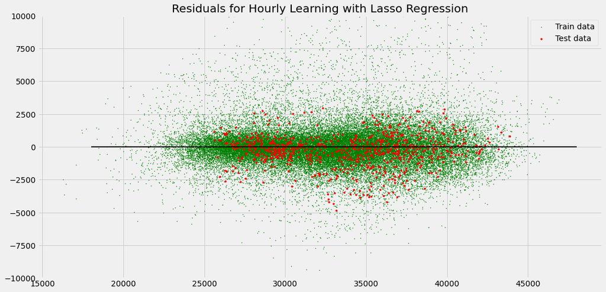

```python
#plot for residual error with hourly lassocv learning
plt.figure(figsize=(16,8))
## setting plot style
plt.style.use('fivethirtyeight')
## plotting residual errors in training data
plt.scatter(train_hold_lasso['Predictions'], (np.array(train_hold_lasso['Predictions'])-np.array(train_hold_lasso['Consumption Amount (MWh)'])),
            color = "green", s = 1, label = 'Train data')
#plotting residual errors in test data
plt.scatter(test_hold_lasso['Predictions'], (np.array(test_hold_lasso['Predictions'])-np.array(test_hold_lasso['Consumption Amount (MWh)'])),
            color = "red", s = 10, label = 'Test data')

#plotting line for zero residual error
plt.hlines(y = 0, xmin = 18000, xmax = 48000, linewidth = 2)
plt.ylim(-10000, 10000)
#plotting legend
plt.legend(loc = 'upper right')

#plot title
plt.title("Residuals for Hourly Learning with Lasso Regression")

#function to show plot
plt.show()
```

```python
lasso_mape_df
```

|  | MAPE |
| --- | --- |
| 0 | 1.525691 |
| 1 | 1.567949 |
| 2 | 1.627949 |
| 3 | 1.781660 |
| 4 | 1.768575 |
| 5 | 2.013284 |
| 6 | 1.967820 |
| 7 | 2.253361 |
| 8 | 3.089663 |
| 9 | 4.057603 |
| 10 | 4.361207 |
| 11 | 4.664913 |
| 12 | 4.598740 |
| 13 | 4.599016 |
| 14 | 4.680529 |
| 15 | 4.251501 |
| 16 | 3.335903 |
| 17 | 2.553805 |
| 18 | 1.684152 |
| 19 | 1.552541 |
| 20 | 1.510047 |
| 21 | 1.538611 |
| 22 | 1.653086 |
| 23 | 1.860445 |

```python
coef
```

|  | Lag_day2_00:00 | Lag_day2_01:00 | Lag_day2_02:00 | Lag_day2_03:00 | Lag_day2_04:00 | Lag_day2_05:00 | Lag_day2_06:00 | Lag_day2_07:00 | Lag_day2_08:00 | Lag_day2_09:00 | ... | Lag_day7_14:00 | Lag_day7_15:00 | Lag_day7_16:00 | Lag_day7_17:00 | Lag_day7_18:00 | Lag_day7_19:00 | Lag_day7_20:00 | Lag_day7_21:00 | Lag_day7_22:00 | Lag_day7_23:00 |
| --- | --- | --- | --- | --- | --- | --- | --- | --- | --- | --- | --- | --- | --- | --- | --- | --- | --- | --- | --- | --- | --- |
| 0. Hour | 1.619494 | -0.691868 | -0.508414 | -0.159878 | 0.584401 | 0.640670 | 0.104200 | 0.243642 | -0.115605 | -0.549653 | ... | 0.229143 | 0.005297 | 0.217475 | 0.150192 | -0.405020 | -0.219449 | -0.334033 | 0.245842 | 0.168110 | 0.192244 |
| 1. Hour | 0.190579 | 1.517797 | -1.138852 | -0.095152 | 0.464494 | 0.608243 | 0.070605 | 0.228521 | -0.126367 | -0.495150 | ... | 0.220981 | -0.060599 | 0.206201 | 0.216500 | -0.431777 | -0.212490 | -0.288505 | 0.312543 | 0.083422 | 0.234050 |
| 2. Hour | 0.132380 | 0.027758 | 1.514511 | -1.033399 | 0.194875 | 0.666192 | 0.085048 | 0.134161 | -0.176082 | -0.438133 | ... | 0.219896 | -0.031705 | 0.158588 | 0.254140 | -0.424874 | -0.186557 | -0.196214 | 0.313539 | 0.033007 | 0.231510 |
| 3. Hour | 0.147149 | 0.050230 | 0.063594 | 1.402569 | -0.896163 | 0.657104 | 0.184300 | 0.102187 | -0.254176 | -0.364619 | ... | 0.195580 | -0.050242 | 0.197705 | 0.252581 | -0.392495 | -0.121959 | -0.304516 | 0.323894 | 0.138406 | 0.185661 |
| 4. Hour | 0.160160 | 0.253122 | -0.242834 | -0.342260 | 1.905378 | -0.229729 | 0.219932 | -0.006701 | -0.159575 | -0.365104 | ... | 0.165388 | -0.080104 | 0.251543 | 0.278514 | -0.474501 | 0.007408 | -0.300615 | 0.094216 | 0.320940 | 0.142627 |
| 5. Hour | 0.260076 | 0.360108 | -0.368019 | -0.323713 | 0.838425 | 0.930030 | 0.054370 | -0.080050 | -0.170042 | -0.218452 | ... | 0.084712 | -0.054721 | 0.334350 | 0.281013 | -0.468167 | 0.155118 | -0.776550 | 0.424303 | 0.225136 | 0.184702 |
| 6. Hour | 0.042845 | 0.314588 | -0.210612 | -0.537488 | 1.139031 | 0.843922 | -0.077062 | 0.034775 | -0.272952 | -0.252329 | ... | -0.115437 | 0.098393 | 0.431837 | 0.331223 | -0.376431 | -0.166428 | -0.495547 | 0.261724 | 0.095412 | 0.201978 |
| 7. Hour | -0.059600 | 0.236722 | -0.324815 | -0.584670 | 1.275420 | 1.312320 | 0.217809 | -0.357059 | -0.209906 | -0.390073 | ... | -0.011687 | -0.068733 | 0.483726 | 0.587921 | -0.630657 | -0.059379 | -0.725868 | 0.353504 | 0.140306 | 0.237513 |
| 8. Hour | -0.089396 | 0.208147 | -0.463396 | -0.822545 | 1.870228 | 2.156737 | -0.010384 | 0.131776 | -0.364183 | -1.050937 | ... | 0.068240 | -0.203162 | 0.796535 | 0.792071 | -1.063604 | 0.144746 | -1.107655 | 0.376260 | 0.468984 | 0.318515 |
| 9. Hour | 0.010475 | 0.160584 | -0.555043 | -1.010264 | 2.102867 | 2.285594 | 0.079321 | 0.474645 | -1.699374 | 0.988872 | ... | -0.092740 | -0.313151 | 1.015282 | 1.093312 | -1.270468 | -0.008467 | -1.167030 | 0.237286 | 0.599720 | 0.465097 |
| 10. Hour | 0.021338 | -0.102872 | -0.513349 | -1.010757 | 2.077747 | 1.927121 | 0.074304 | 0.870738 | -0.928520 | -1.733160 | ... | -0.223463 | -0.444860 | 1.300246 | 0.922330 | -1.215526 | -0.200190 | -1.122531 | 0.368661 | 0.459992 | 0.435837 |
| 11. Hour | 0.119884 | -0.195671 | -0.519354 | -0.941031 | 1.936320 | 1.745581 | 0.096374 | 1.052001 | -0.880226 | -1.717536 | ... | -0.250777 | -0.487448 | 1.231223 | 1.123923 | -1.241931 | -0.364684 | -1.065212 | 0.381587 | 0.414533 | 0.423465 |
| 12. Hour | -0.161510 | -0.025472 | -0.586596 | -0.942153 | 2.032643 | 1.245566 | 0.139286 | 1.044587 | -0.453370 | -1.405016 | ... | -0.269100 | -0.433636 | 0.983191 | 0.879274 | -1.001243 | -0.358563 | -0.999549 | 0.239505 | 0.710560 | 0.370707 |
| 13. Hour | -0.026019 | -0.050216 | -0.640654 | -0.821944 | 1.757647 | 1.249162 | 0.036656 | 1.404272 | -0.760538 | -1.273986 | ... | 0.183739 | -0.743699 | 0.815488 | 0.690161 | -0.875364 | -0.344703 | -0.915744 | 0.251122 | 0.875810 | 0.344425 |
| 14. Hour | -0.082504 | -0.032747 | -0.645998 | -0.852446 | 1.953609 | 1.338920 | 0.113030 | 1.344951 | -0.667837 | -1.371534 | ... | 0.601298 | -0.557967 | 0.928085 | 0.635562 | -0.905943 | -0.374707 | -0.988830 | 0.408862 | 0.921647 | 0.317401 |
| 15. Hour | -0.012106 | -0.083275 | -0.781087 | -0.750891 | 1.895062 | 1.401721 | 0.172149 | 1.211428 | -0.717192 | -1.376195 | ... | 0.640145 | 0.096935 | 0.225871 | 0.688652 | -0.850949 | -0.357564 | -1.063355 | 0.506213 | 0.940797 | 0.335978 |
| 16. Hour | -0.082868 | -0.087038 | -0.761440 | -0.725710 | 1.875779 | 1.403747 | 0.267270 | 1.013464 | -0.712437 | -1.431396 | ... | 0.731262 | -0.040682 | 0.130964 | 0.897475 | -0.942267 | -0.220765 | -1.123277 | 0.561060 | 0.965919 | 0.325782 |
| 17. Hour | -0.077054 | -0.063870 | -0.919447 | -0.455193 | 1.687842 | 1.150859 | 0.198499 | 0.879383 | -0.549762 | -1.490701 | ... | 0.542658 | 0.074539 | 0.744183 | -0.734427 | 0.266636 | -0.359683 | -1.002229 | 0.598556 | 0.945837 | 0.198141 |
| 18. Hour | -0.078762 | -0.141217 | -0.759326 | -0.409782 | 1.343575 | 0.803635 | 0.270712 | 0.667685 | -0.326516 | -1.125142 | ... | 0.291870 | -0.022682 | 0.345192 | 0.229917 | -0.705296 | -0.044417 | -0.726220 | 0.506163 | 0.447169 | 0.164908 |
| 19. Hour | 0.090593 | -0.248678 | -0.899568 | -0.505448 | 1.446239 | 0.849081 | 0.085712 | 0.508163 | -0.233212 | -0.927379 | ... | 0.192513 | -0.047495 | 0.364155 | 0.139811 | -0.536955 | -0.081360 | -0.837815 | 0.633916 | 0.317159 | 0.148053 |
| 20. Hour | 0.195223 | -0.242142 | -0.634177 | -0.185496 | 1.007799 | 0.462832 | 0.218771 | 0.419228 | -0.211199 | -0.835784 | ... | 0.250287 | -0.060852 | 0.295351 | 0.112016 | -0.432807 | -0.251229 | 0.247795 | -0.305856 | 0.289234 | 0.138898 |
| 21. Hour | 0.064095 | -0.247242 | -0.733313 | -0.089997 | 0.763052 | 0.748373 | 0.214366 | 0.399171 | -0.263392 | -0.778982 | ... | 0.173983 | 0.021000 | 0.239449 | 0.163270 | -0.456906 | -0.237166 | -0.556289 | 0.843037 | -0.046154 | 0.103393 |
| 22. Hour | -0.170320 | -0.230372 | -0.621248 | -0.199695 | 0.823602 | 0.725233 | 0.185512 | 0.268394 | -0.162093 | -0.742397 | ... | 0.135731 | 0.035448 | 0.267278 | 0.133378 | -0.411638 | -0.251162 | -0.559025 | 0.505463 | 0.380817 | 0.020907 |
| 23. Hour | -0.534047 | -0.295288 | -0.489982 | -0.113920 | 0.659211 | 0.721849 | 0.076382 | 0.231775 | -0.083729 | -0.690315 | ... | 0.185778 | -0.008266 | 0.247829 | 0.143250 | -0.372925 | -0.258954 | -0.536318 | 0.464930 | 0.104359 | 0.308187 |

24 rows × 48 columns

```python
lasso_mape_df.describe()
```

|  | MAPE |
| --- | --- |
| count | 24.000000 |
| mean | 2.687419 |
| std | 1.254915 |
| min | 1.510047 |
| 25% | 1.646802 |
| 50% | 1.990552 |
| 75% | 4.106077 |
| max | 4.680529 |

Comment for question d) In this question lasso regression is implemented. At first glance, MAPE values for each hour period seems appropriate. Moreover, they seems better than even results in part c. Mean value of all hour MAPE is 2.687% and standard deviation is 1.254%. These results very good for accuracy. Minimum deviation is resulted in the data which covers time period 20:00 (%1.51) while maximum deviation is resulted in the time period 14:00 (%4.68). The seasonality effect like in part c, shows itself in this question again. In working hours, fluctuation increases. This causes an increase in deviation and MAPE. Besides, in coef dataframe, coefficient or values of beta for lasso regression exist. Minus sign means that the lag period affect inversely the consumption. Also, absolute value of coefficient shows the effect size. Coefficient has bigger absolute value can be considered as significant. Moreover, in the residual plot, the majority of deviations are close to zero except outliers. Among approaches conducted till part d, lasso regression gives the best results with the mean value of 2.687%.

# Question f)

```python
#import packages for box plot
import seaborn as sns
```

```python
#create dataframe which includes absolute percentage error for all test with questions a,b,c,d
frame = { 'QA-lag168': qa_lag168, 'QA-lag48': qa_lag48, 'QB-Reg': qb_reg, 'QC-Reg': qc_reg, 'QD-lasso': qd_lasso}
result = pd.DataFrame(frame)
result
```

|  | QA-lag168 | QA-lag48 | QB-Reg | QC-Reg | QD-lasso |
| --- | --- | --- | --- | --- | --- |
| 0 | 2.716606 | 1.271322 | 2.818064 | 2.434671 | 1.776381 |
| 1 | 2.745013 | 2.145508 | 3.396694 | 4.551730 | 0.057391 |
| 2 | 3.975755 | 3.303632 | 4.805747 | 4.876415 | 8.578365 |
| 3 | 3.794342 | 3.188004 | 4.802183 | 6.536404 | 3.347810 |
| 4 | 2.965802 | 3.056191 | 4.258923 | 3.392994 | 0.478567 |
| ... | ... | ... | ... | ... | ... |
| 739 | 0.429787 | 10.828518 | 4.002538 | 1.932166 | 1.298410 |
| 740 | 0.114579 | 9.727231 | 3.715480 | 0.906779 | 2.212484 |
| 741 | 0.145181 | 9.969359 | 3.677998 | 5.345782 | 3.020708 |
| 742 | 0.733739 | 9.350172 | 2.982840 | 2.429599 | 2.100934 |
| 743 | 1.291432 | 9.600212 | 2.529932 | 4.290162 | 0.497180 |

744 rows × 5 columns

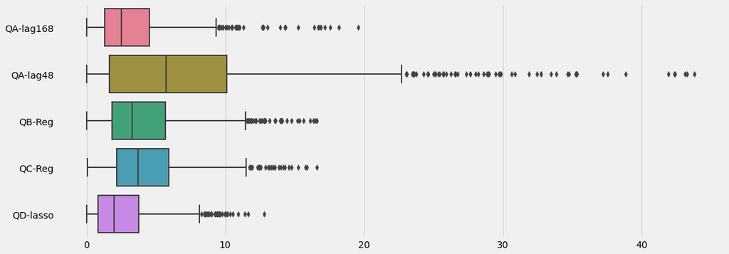

```python
#box plot
plt.figure(figsize=(16, 6))
ax = sns.boxplot(data=result, orient="h", palette="husl" ,linewidth=2)
```

Comment for question f): If we look at the boxplot above, QA-lag48 gives the worst result in which some cases gives huge deviation that are bigger than 40%. On the other hand, QA-lag168 gives better result than QA-lag48 and its median is near the %3; however, there are a lot of outliers in the QA-lag168 and some outliers near the 20%. That situation decreases the reliability. Moreover, boxplot of QB-Reg and QC-Reg are approximately same and their values of median are near the 3%. Finally, QD-lasso gives the best boxplot for accuracy. Its median is near 1.99% and its mean which is founded in question d, is 2.68%. As it was said before, this the best value for accuracy among all approaches. Also, in QD-lasso, outliers is more close the interquartile range than other approaches. This is positive situation for QD-lasso, also its outlier with maximum value is less than others have.